# Exercise 1 - TMA4300 Computer Intensive Statistical Methods

# Problem A

## Question 1

We first want to write an R function that generates samples from a exponential distribution with rate parameter $\lambda$. We know that the cumulative exponential distrobution takes the form
$$F(x;\lambda) = 1 - \lambda e ^{-\lambda x}, \quad x \ge 0$$

Computing the inverse cumulative function exploiting the uniform distribution $U \sim Unif(0,1)$ we can get
$$X = F^{-1}(u) = - ln (u)/\lambda, \quad 0 \leq u \leq 1$$

We now want to show that this is true using simulation from the inverse cumulative distribution

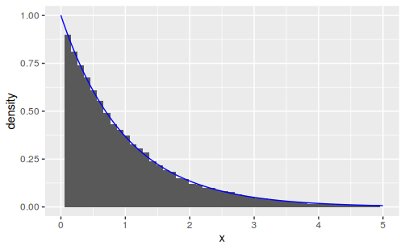

```r
# n: number of samples to generate
# rate: the rate
# expdist returns a vector with generated random numbers from exponential distribution
expdist <- function(rate, n) {
   u <- runif(n)
   x <-  -log( (1/rate)*( 1 - u))/rate
   list = list(x, u)
   return(list)
}
n <- 60000
lambda <- 1
outval <- expdist(lambda, n)
x = outval[[1]]
y = outval[[2]]
library(ggplot2)
ggplot(data.frame(x=x))+geom_histogram(aes(x=x, y = ..density..), bins = 50)+geom_line(data = data.frame(x=x,y=dexp(x, rate = 1)), aes(x=x, y=y), color = "blue")+xlim(0,5)
```

From the plot one can see that the exponential distribtion that we generated and the exponential distribution in R closely follow each other, which means that our implementation is correct.

## Question 2 a

Let us consider a new example where the PDF has the form
$$g(x) =
\begin{cases}
cx^{\alpha -1},& \quad 0 < x < 1 \\
ce^{-x},& \quad x \ge 1 \\
\end{cases}$$

The cumulative function can be computed with integration

$$\begin{align}
G(x) &=
\begin{cases}
\int_0^x c x^{\alpha- 1}dx ,& \quad 0 < x < 1 \\
\int_0^1c x^{\alpha- 1}dx + \int_1^x c e^{-x}dx ,& \quad x \ge 1 \\
0, &\quad \text{otherwise}
\end{cases} \\
& =
\begin{cases}
\frac{c}{\alpha}x^{\alpha},& \quad 0 < x < 1 \\
\frac{c}{\alpha} + ce^{-1} + -ce^{-x} ,& \quad x \ge 1 \\
0, &\quad \text{otherwise}
\end{cases} \\
& =
\begin{cases}
\frac{c}{\alpha}x^{\alpha},& \quad 0 < x < 1 \\
c \frac{\alpha + e}{e \alpha} -ce^{-x} ,& \quad x \ge 1 \\ 0, &\quad \text{otherwise}
\end{cases} \\
\end{align}$$

with c as $\frac{e\alpha}{e+\alpha}$ in all the expressions, which is found by using that the density integrated over the whole space must be 1.

And similarly with the inverse cumulative function is

$$G^{-1} (u) = \begin{cases}
(\frac{u\alpha}{c})^{\frac{1}{\alpha}}, \quad 0<u < c/\alpha \\
-ln(\frac{\alpha + e}{e \alpha} - u/c), \quad u \geq c/\alpha \\
0, \quad \text{otherwise}
\end{cases}$$

## Question 2 b

This distribution can be plotted by using the inverse cumulative distribution as before.

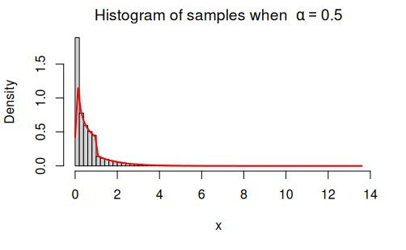

```r
# ca: normalizing constant
ca <- function(alpha) {
  return(exp(1)*alpha/(exp(1)+alpha))
}
# alpha: parameter alpha
# n: number of samples to generate
# dist1 returns a vector of random numbers from the distribution g
dist1 <- function(alpha, n) {
   u <- runif(n)
   L = u<ca(alpha)/alpha
   res = c(1:n)*0
   res[L] = (u[L]*alpha/ca(alpha))^(1/alpha)
   res[!L] = -log((1-u[!L])/ca(alpha))
   return(list(res,u))
}

g_test = function(alpha, x) {
  res = c(1:length(x))*0
  L = x<1&x>0
  res[L] = ca(alpha)*x[L]^(alpha-1)
  res[!L] = ca(alpha)*exp(-x[!L])
  return (res)
}

n <- 60000
alpha <- 0.5
outval1 <- dist1(alpha, n)
x <- outval1[[1]]
y <- outval1[[2]]

hist(x, breaks = 50, freq = FALSE, main = bquote("Histogram of samples when "~alpha == .(alpha)))
curve(g_test(alpha, x), col = "red", lwd = 2, add=TRUE)
```

## Question 3 b

By integrating the PDF from $-\inf$ to x, we find the CDF:
$$F(x) = \frac{-1}{1+e^{\alpha x}}+1$$
and the inverse of F is found by solving for x (where $F(x)$ is $y$:
$$F^{-1}(x) = \frac{1}{\alpha}ln(\frac{-y}{y-1})$$

## Question 3 c

We want to use the inversion method to generate random samples from the distribution in question 3b, and compare them with the theoretical values.

```r
# alpha: the parameter alpha
# n: number of samples to be generated
# dist3 gives a vector of random variables from the distribution in question 3b
dist3 <- function(alpha, n) {
   u <- runif(n)
   x <- 1/alpha*log(-u/(u-1))
   list = list(x, u)
   return(list)
}
# checkfunc3 gives values from the theoretical function that we want to check with
x <- seq(from = -10, to = 10, length.out = 100)
checkfunc3 <- function(alpha, x) {
  return(alpha*exp(alpha*x)/(1+exp(alpha*x))^2)
}
outval3 <- dist3(alpha, n)
ggplot(data.frame(x = outval3[[1]], y = outval3[[2]]))+
  geom_histogram(aes(x=x, y=..density..),alpha=0.2)+geom_line(data = data.frame(x=x,y=checkfunc3(alpha,x)), aes(x=x, y=y), color = "blue")
```

[output not shown]